# 12_GAN

## 5.1. Conditional GAN Implimentation

Rather than studying cGAN theoretically, we will go through a hands-on implementation using the MNIST dataset. This will make the key ideas — how the conditioning information is incorporated into both networks, how training proceeds, and what the results look like — concrete and intuitive.

```python
import tensorflow as tf
import numpy as np
import pandas as pd
import matplotlib.pyplot as plt
%matplotlib inline
```

```python
(train_x, train_y), (test_x, test_y) = tf.keras.datasets.mnist.load_data()

train_x, test_x = train_x/255.0 , test_x/255.0
train_x, test_x = train_x.reshape(-1,784), test_x.reshape(-1,784)

train_y = tf.keras.utils.to_categorical(train_y, num_classes = 10)
test_y = tf.keras.utils.to_categorical(test_y, num_classes = 10)

print('train_x: ', train_x.shape)
print('test_x: ', test_x.shape)
print('train_y: ', train_y.shape)
print('test_y: ', test_y.shape)
```

```
train_x:  (60000, 784)
test_x:  (10000, 784)
train_y:  (60000, 10)
test_y:  (10000, 10)
```

In cGAN, the generator takes both a noise vector $z$ and a conditioning variable $c$ as input. Here, the conditioning variable is the class label $c$, represented as a one-hot encoded vector of dimension 10 — one element for each digit in MNIST.

The noise vector $z$ has dimension 128, and the label vector $c$ has dimension 10. The two are concatenated before being fed into the network, giving a combined input dimension of $128 + 10 = 138$.

By concatenating $z$ and $c$, the generator learns to produce images that correspond to the specified digit. For example, when $c = [0, 1, 0, 0, 0, 0, 0, 0, 0, 0]$ (the one-hot encoding for digit 1), the generator is expected to produce an image that looks like a handwritten 1.

```python
generator_model = tf.keras.models.Sequential([
    tf.keras.layers.Dense(units = 256, activation = 'relu', input_dim = 138),
    tf.keras.layers.Dense(units = 784, activation = 'sigmoid')
])

noise = tf.keras.layers.Input(shape = (128,))
label = tf.keras.layers.Input(shape = (10,))

model_input = tf.keras.layers.concatenate([noise, label], axis = 1)
generated_image = generator_model(model_input)

generator = tf.keras.models.Model(inputs = [noise, label], outputs = generated_image)
```

```python
generator.summary()
```

```
Model: "model_3"
__________________________________________________________________________________________________
 Layer (type)                   Output Shape         Param #     Connected to
==================================================================================================
 input_7 (InputLayer)           [(None, 128)]        0           []

 input_8 (InputLayer)           [(None, 10)]         0           []

 concatenate_2 (Concatenate)    (None, 138)          0           ['input_7[0][0]',
                                                                  'input_8[0][0]']

 sequential_2 (Sequential)      (None, 784)          237072      ['concatenate_2[0][0]']

==================================================================================================
Total params: 237,072
Trainable params: 237,072
Non-trainable params: 0
__________________________________________________________________________________________________
```

Similarly, the discriminator in cGAN takes both an image and a conditioning label as input. The image has dimension 784 (28×28 pixels), and the label is a one-hot encoded vector of dimension 10. The two are concatenated before being fed into the network, giving a combined input dimension of $784 + 10 = 794$.

By conditioning the discriminator on the label $c$, it learns to evaluate not just whether an image looks real, but whether it looks like a plausible example of the specified digit. For instance, if $c$ corresponds to digit 3, the discriminator must judge whether the input image looks like a realistic handwritten 3 — not just a realistic digit in general.

```python
discriminator_model = tf.keras.models.Sequential([
    tf.keras.layers.Dense(units = 256, activation = 'relu', input_dim = 794),
    tf.keras.layers.Dense(units = 1, activation = 'sigmoid')
])

input_image = tf.keras.layers.Input(shape = (784,))
label = tf.keras.layers.Input(shape = (10,))

model_input = tf.keras.layers.concatenate([input_image, label], axis = 1)
validity = discriminator_model(model_input)

discriminator = tf.keras.models.Model(inputs = [input_image, label], outputs = validity)
```

```python
discriminator.compile(optimizer = tf.keras.optimizers.Adam(learning_rate = 0.0002),
                      loss = ['binary_crossentropy'])
```

```python
discriminator.summary()
```

```
Model: "model_4"
__________________________________________________________________________________________________
 Layer (type)                   Output Shape         Param #     Connected to
==================================================================================================
 input_9 (InputLayer)           [(None, 784)]        0           []

 input_10 (InputLayer)          [(None, 10)]         0           []

 concatenate_3 (Concatenate)    (None, 794)          0           ['input_9[0][0]',
                                                                  'input_10[0][0]']

 sequential_3 (Sequential)      (None, 1)            203777      ['concatenate_3[0][0]']

==================================================================================================
Total params: 203,777
Trainable params: 203,777
Non-trainable params: 0
__________________________________________________________________________________________________
```

```python
discriminator.trainable = False

noise = tf.keras.layers.Input(shape = (128,))
label = tf.keras.layers.Input(shape = (10,))

generated_image = generator([noise, label])
validity = discriminator([generated_image, label])

combined = tf.keras.models.Model(inputs = [noise, label], outputs = validity)
```

```python
combined.compile(optimizer = tf.keras.optimizers.Adam(learning_rate = 0.0002),
                      loss = ['binary_crossentropy'])
```

```python
combined.summary()
```

```
Model: "model_5"
__________________________________________________________________________________________________
 Layer (type)                   Output Shape         Param #     Connected to
==================================================================================================
 input_11 (InputLayer)          [(None, 128)]        0           []

 input_12 (InputLayer)          [(None, 10)]         0           []

 model_3 (Functional)           (None, 784)          237072      ['input_11[0][0]',
                                                                  'input_12[0][0]']

 model_4 (Functional)           (None, 1)            203777      ['model_3[0][0]',
                                                                  'input_12[0][0]']

==================================================================================================
Total params: 440,849
Trainable params: 237,072
Non-trainable params: 203,777
__________________________________________________________________________________________________
```

```python
def create_noise(samples):
    return np.random.normal(0, 1, [samples, 128])
```

```python
def plot_generated_images(generator):

    noise = create_noise(10)
    label = np.arange(0, 10).reshape(-1, 1)
    label_onehot = np.eye(10)[label.reshape(-1)]

    generated_images = generator.predict([noise, label_onehot])

    plt.figure(figsize = (12, 3))
    for i in range(generated_images.shape[0]):
        plt.subplot(1, 10, i + 1)
        plt.imshow(generated_images[i].reshape((28, 28)), 'gray', interpolation = 'nearest')
        plt.title('Digit: {}'.format(i))
        plt.axis('off')

    plt.show()
```

```
Discriminator Loss:  1.5396462678909302
Generator Loss:  0.8892247676849365
```

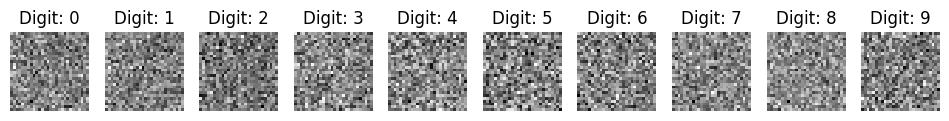

```
Discriminator Loss:  0.09676432050764561
Generator Loss:  4.2714643478393555
```

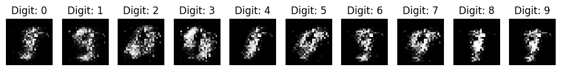

```
Discriminator Loss:  0.08658699691295624
Generator Loss:  5.2906494140625
```

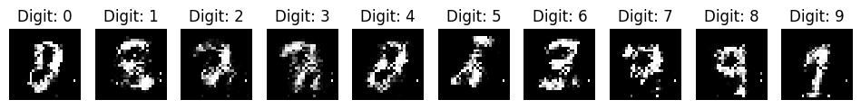

```
Discriminator Loss:  0.21492188423871994
Generator Loss:  4.767454147338867
```

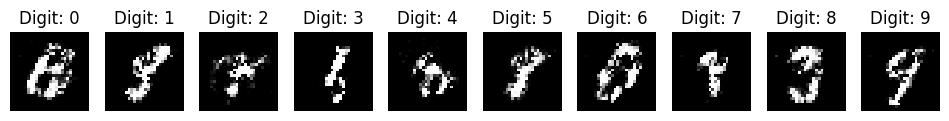

```
Discriminator Loss:  1.4001021981239319
Generator Loss:  1.8565527200698853
```

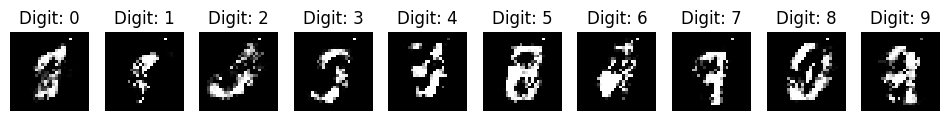

```
Discriminator Loss:  0.19797339290380478
Generator Loss:  4.865542888641357
```

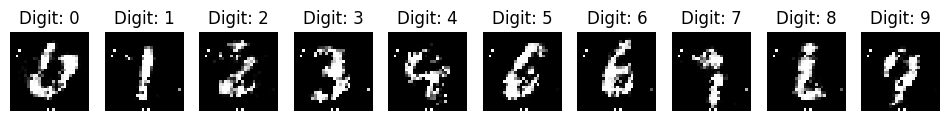

```python
n_iter = 30000
batch_size = 50

valid = np.ones(batch_size)
fake = np.zeros(batch_size)

for i in range(n_iter):

    # Train Discriminator
    idx = np.random.randint(0, train_x.shape[0], batch_size)
    real_images, labels = train_x[idx], train_y[idx]

    noise = create_noise(batch_size)
    generated_images = generator.predict([noise,labels], verbose = 0)

    d_loss_real = discriminator.train_on_batch([real_images, labels], valid)
    d_loss_fake = discriminator.train_on_batch([generated_images, labels], fake)
    d_loss = d_loss_real + d_loss_fake

    # Train Generator
    noise = create_noise(batch_size)
    labels = np.random.randint(0, 10, batch_size)
    labels_onehot = np.eye(10)[labels]

    g_loss = combined.train_on_batch([noise, labels_onehot], valid)

    if i % 5000 == 0:

        print('Discriminator Loss: ', d_loss)
        print('Generator Loss: ', g_loss)

        plot_generated_images(generator)
```

## 5.2. Meaning of Latent Space in cGAN

The cGAN implementation above demonstrates the core idea of conditional generation, even if the quality of the generated images leaves room for improvement. One important question worth asking at this point is: what does the latent space actually represent in a cGAN, and how is it different from a standard GAN?

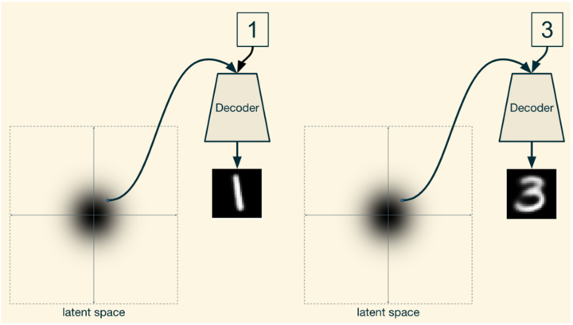

In a standard GAN, the position in the latent space determines everything about the generated image — both what digit it is and what it looks like. Different positions in the latent space correspond to different digit classes as well as different visual styles.

In cGAN, the class information is provided separately through the conditioning label $c$. This frees the latent space from having to encode class identity. Instead, the latent space only needs to encode lower-level visual features such as stroke width, angle, or writing style.

As shown in the figure, the same point in the latent space can be used to generate two completely different digits — a 1 and a 3 — simply by changing the conditioning label. The latent point encodes how the digit is written, while the label determines which digit is written.

This separation makes the latent space more interpretable and the generation process more controllable:

- The conditioning label $c$ controls the class — which digit to generate
- The latent code $z$ controls the style — features such as stroke width or angle that are shared across all digit classes

In practice, this means we can fix $z$ and vary $c$ to generate different digits with the same handwriting style, or fix $c$ and vary $z$ to generate different styles of the same digit.

# 6. InfoGAN (Information Maximizing GAN)

The cGAN result above raises a natural question: what if we do not have class labels? In cGAN, the conditioning label $c$ must be provided explicitly at training time — meaning we need a labeled dataset. This is a significant limitation when labels are unavailable or expensive to obtain.

In a standard generative model, there is no control over the features of the data being generated. The noise vector $z$ encodes everything about the generated image — digit identity, stroke width, angle, and any other factor of variation — all entangled together in a single unstructured vector. There is no way to manipulate one factor independently of the others. Changing a single dimension of $z$ may simultaneously affect the digit class, the thickness of the strokes, and the tilt of the character in unpredictable ways.

InfoGAN addresses this with a simple but powerful modification to the standard GAN framework. A separate latent code $c$ is introduced alongside the noise vector $z$, and the generator is encouraged to use $c$ to encode distinct, interpretable factors of variation in a disentangled way — learned entirely through unsupervised learning, without any labels. The generator takes both as input:

$$G(z, c) \rightarrow \hat{x}$$

The problem is that without any constraint, the generator will simply ignore $c$ and encode everything in $z$, leaving $c$ entangled with or irrelevant to the output. To prevent this, InfoGAN adds a constraint: the generated image $G(z, c)$ must retain enough information to recover $c$ from it. In other words, if we look at a generated image, we should be able to tell what value of $c$ was used to produce it. This is what mutual information $I(c;\, G(z, c))$ measures — how much knowing the generated image tells us about $c$.

Maximizing this quantity forces $c$ to encode something meaningful and consistent about the output, pushing the model toward a disentangled representation where each dimension of $c$ corresponds to an independent, interpretable factor. The full objective is:

$$\min_G \max_D \; \mathbb{E}_{x \sim p_{\text{data}}}[\log D(x)] + \mathbb{E}_{z, c}[\log(1 - D(G(z, c)))] - \lambda I(c;\, G(z, c))$$

To compute this in practice, an auxiliary network $Q$ is added to the framework. $Q$ takes a generated image $\hat{x}$ as input and predicts the latent code $c$ that was used to produce it. If $Q$ can accurately recover $c$ from $G(z, c)$, it means the generated image carries clear information about $c$ — and the mutual information is high. Training $Q$ to predict $c$ well is therefore equivalent to maximizing the mutual information. In practice, $Q$ shares most of its layers with the discriminator $D$, so it adds very little computational overhead.

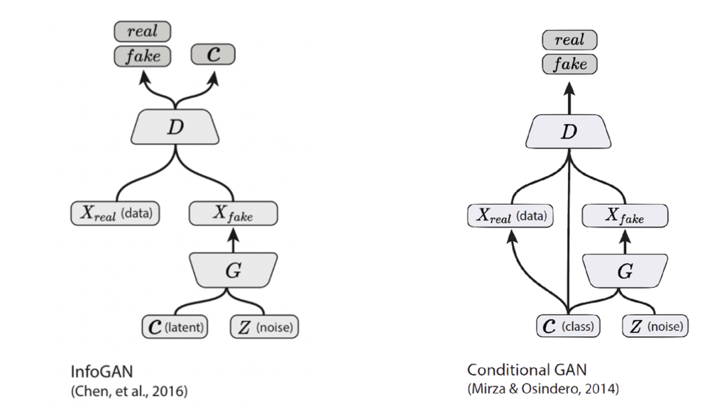

The latent code $c$ can take various forms. For continuous codes, $c$ typically takes values in the range $[-1, 1]$, encoding smooth, continuous factors of variation such as stroke width or rotation angle. For discrete codes, $c$ can represent categorical information such as digit class.

The three networks — $G$, $D$, and $Q$ — are trained jointly, and the generative model learns interpretable information from the data entirely by itself.

The two figures below show concrete examples of what InfoGAN learns on MNIST when two continuous latent codes are used.

- In the first figure, varying one continuous latent code from left to right produces digit 2s with progressively changing rotation angle — the digit gradually tilts as the code value changes.
- In the second figure, varying the other continuous latent code produces digit 2s with progressively changing curvature in the tail — from a sharply curved tail on the left to a more rounded, looped style on the right.

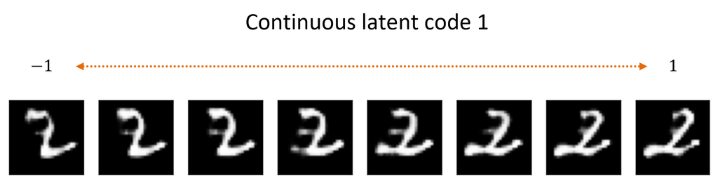

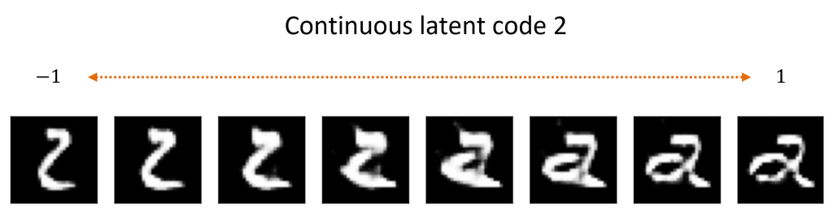

It is important to note that these factors — rotation and tail curvature — were never specified in advance. InfoGAN did not receive any instruction to discover them. They emerged entirely from unsupervised learning, driven only by the mutual information constraint. The interpretation of what each latent code represents is something we as humans infer after training by observing how the generated images change as each code is varied. The model simply learns whatever structure in the data is most consistent and informative — and it is up to us to give that structure a name.

## 6.1. Meaning of Latent Space in InfoGAN

The figure illustrates how the generator in InfoGAN operates at inference time. The same point in the latent space $z$ is used in both cases, but the continuous latent code $c$ is set to $-1$ on the left and $+1$ on the right. The resulting images show the same digit 2 with a noticeably different visual style — demonstrating that the latent code independently controls an interpretable factor of variation while the latent point remains fixed.

This is the key advantage of InfoGAN over a standard GAN. By fixing $z$ and varying $c$, we can control specific attributes of the generated output in a predictable and interpretable way — without any labels or explicit supervision. The latent space $z$ and the latent code $c$ each play a distinct role: $z$ determines the general characteristics of the sample drawn from the data distribution, while $c$ provides fine-grained control over the interpretable factors that InfoGAN has learned to disentangle from the data.

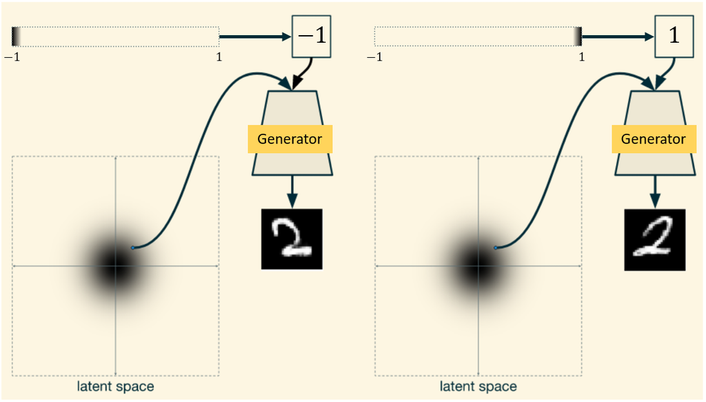

## 6.2. InfoGAN Implementation

**Deep Convolutional GAN (DCGAN)**

All of the GAN examples so far have used fully connected neural networks for both the generator and the discriminator. While this is sufficient to demonstrate the core ideas, fully connected networks are not well suited for image generation — they do not exploit the spatial structure of images and scale poorly to higher resolutions.

DCGAN is a direct extension of the standard GAN framework that addresses this by replacing fully connected layers with convolutional and convolutional-transpose layers in the discriminator and generator, respectively. Convolutional layers are well suited for image data because they capture local spatial patterns and are invariant to the position of features within the image. As a result, DCGAN produces significantly higher quality images than a fully connected GAN, and has become the standard backbone architecture for image generation tasks — including InfoGAN, which we will implement next.

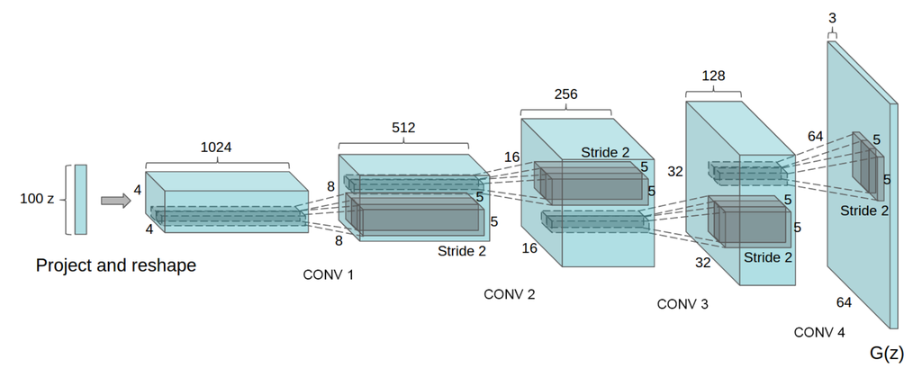

**(Simple) InfoGAN Structure as an Example**

The figure below shows the DCGAN architecture used as the backbone for our InfoGAN implementation. To keep things simple, the model is trained to generate only the digit 2, and two continuous latent codes are used for $c$.

- The generator takes a noise vector $z$ as input and progressively expands it into a full image through a series of convolutional-transpose layers.
- The discriminator follows the opposite direction. It takes a 28$\times$28 image as input and passes it through a series of convolutional layers, eventually producing a single scalar output — the probability that the input image is real.
- In the InfoGAN extension, the $Q$ network shares the convolutional layers of the discriminator and adds a separate fully connected branch of 128 units on top. This branch outputs the predicted values of the two continuous latent codes $c_1$ and $c_2$. Since $Q$ reuses the discriminator's feature extraction layers, it adds minimal computational overhead while enabling the model to learn disentangled representations from the data.

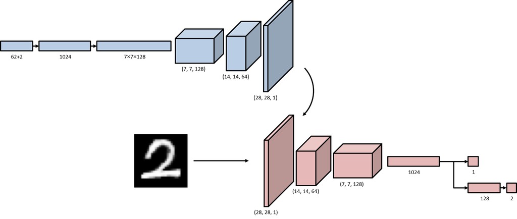

```python
import numpy as np
import matplotlib.pyplot as plt
import tensorflow as tf
```

```python
(train_x, train_y), _ = tf.keras.datasets.mnist.load_data()

train_x = train_x[np.where(train_y == 2)]
train_x = train_x/255.0
train_x = train_x.reshape(-1, 28, 28, 1)

print('train_iamges :', train_x.shape)
```

```
Downloading data from https://storage.googleapis.com/tensorflow/tf-keras-datasets/mnist.npz
train_iamges : (5958, 28, 28, 1)
```

The generator takes a concatenated input of dimension 62 + 2 = 64, where 62 dimensions correspond to the noise vector $z$ and 2 dimensions correspond to the continuous latent codes $c_1$ and $c_2$.

```python
generator = tf.keras.models.Sequential([
    tf.keras.layers.Dense(units = 1024,
                          use_bias = False,
                          input_shape = (62 + 2,)),
    tf.keras.layers.BatchNormalization(),
    tf.keras.layers.ReLU(),
    tf.keras.layers.Dense(units = 7*7*128,
                          use_bias = False),
    tf.keras.layers.BatchNormalization(),
    tf.keras.layers.ReLU(),
    tf.keras.layers.Reshape((7, 7, 128)),
    tf.keras.layers.Conv2DTranspose(64,
                                    (4, 4),
                                    strides = (2, 2),
                                    padding = 'same',
                                    use_bias = False),
    tf.keras.layers.BatchNormalization(),
    tf.keras.layers.ReLU(),
    tf.keras.layers.Conv2DTranspose(1,
                                    (4, 4),
                                    strides = (2, 2),
                                    padding = 'same',
                                    use_bias = False,
                                    activation = 'sigmoid')
])
```

The discriminator in InfoGAN is structured around three components that share a common feature extraction backbone.

- The `extractor` network takes a 28$\times$28$\times$1 image as input, producing a 1024-dimensional feature vector. This shared feature vector is then consumed by both the `d_network` and the `q_network`.
- The `d_network` takes the 1024-dimensional feature vector and maps it to a single scalar output via a sigmoid activation — the probability that the input image is real. This is the standard discriminator output.
- The `q_network` takes the same 1024-dimensional feature vector and passes it through an additional fully connected layer of 128 units, followed by a final layer that outputs 2 values — the predicted values of the continuous latent codes $c_1$ and $c_2$.

By sharing the `extractor` between `d_network` and `q_network`, the discriminator and $Q$ network are trained jointly on the same feature representation. The `d_network` learns to distinguish real from fake images, while the `q_network` learns to recover the latent codes $c$ from the generated images — enforcing the mutual information constraint without significant additional computational cost.

```python
extractor = tf.keras.models.Sequential([
    tf.keras.layers.Conv2D(64,
                           (4, 4),
                           strides = (2, 2),
                           padding = 'same',
                           use_bias = False,
                           input_shape = [28, 28, 1]),
    tf.keras.layers.LeakyReLU(),
    tf.keras.layers.Conv2D(128,
                           (4, 4),
                           strides = (2, 2),
                           padding = 'same',
                           use_bias = False),
    tf.keras.layers.LayerNormalization(),
    tf.keras.layers.LeakyReLU(),
    tf.keras.layers.Flatten(),
    tf.keras.layers.Dense(units = 1024,
                          use_bias = False),
    tf.keras.layers.LayerNormalization(),
    tf.keras.layers.LeakyReLU()
])
```

```python
d_network = tf.keras.models.Sequential([
    tf.keras.layers.Dense(units = 1,
                          input_shape = (1024,),
                          use_bias = False,
                          activation = 'sigmoid')
])
```

```python
q_network = tf.keras.models.Sequential([
    tf.keras.layers.Dense(units = 128,
                          use_bias = False,
                          input_shape = (1024,)),
    tf.keras.layers.LayerNormalization(),
    tf.keras.layers.LeakyReLU(),
    tf.keras.layers.Dense(units = 2,
                          use_bias = False)
])
```

```python
combined_input = tf.keras.layers.Input(shape = (28, 28, 1))
combined_feature = extractor(combined_input)
combined_output = d_network(combined_feature)

discriminator = tf.keras.models.Model(inputs = combined_input,
                                      outputs = combined_output)
```

```python
discriminator.compile(optimizer = tf.keras.optimizers.Adam(learning_rate = 2e-4),
                      loss = 'binary_crossentropy')
```

```python
extractor.trainable = False
d_network.trainable = False

combined_input = tf.keras.layers.Input(shape = (62 + 2,))
generated = generator(combined_input)
combined_feature = extractor(generated)
combined_output = d_network(combined_feature)

combined_d = tf.keras.models.Model(inputs = combined_input,
                                   outputs = combined_output)
```

```python
combined_d.compile(optimizer = tf.keras.optimizers.Adam(learning_rate = 1e-3),
                   loss = 'binary_crossentropy')
```

```python
extractor.trainable = False
d_network.trainable = False

combined_input = tf.keras.layers.Input(shape = (62 + 2,))
generated = generator(combined_input)
combined_feature = extractor(generated)
combined_latent = q_network(combined_feature)

combined_q = tf.keras.models.Model(inputs = combined_input,
                                   outputs = combined_latent)
```

```python
combined_q.compile(optimizer = tf.keras.optimizers.Adam(learning_rate = 1e-3),
                   loss = 'mean_squared_error')
```

```python
def make_noise(samples):
    return np.random.uniform(-1, 1, size = [samples, 62])

def make_code(samples):
    return 2*np.random.rand(samples, 2) - 1
```

```python
def plot_generated_images(generator):
    z = np.random.randn(1, 62).repeat(5, axis = 0)
    c = np.stack([np.linspace(-1, 1, 5), np.zeros(5)]).T
    noise = np.concatenate([z, c], -1)

    generated_images = generator.predict(noise, verbose = 0)
    generated_images = generated_images.reshape(5, 28, 28)

    print('')
    print('Continuous Latent Code 1')
    for i in range(5):
        plt.subplot(1, 5, i+1)
        plt.imshow(generated_images[i], 'gray', interpolation = 'nearest')
        plt.axis('off')
        plt.tight_layout()
    plt.show()

    z = np.random.randn(1, 62).repeat(5, axis = 0)
    c = np.stack([np.zeros(5), np.linspace(-1, 1, 5)]).T
    noise = np.concatenate([z, c], -1)

    generated_images = generator.predict(noise, verbose = 0)
    generated_images = generated_images.reshape(5, 28, 28)

    print('Continuous Latent Code 2')
    for i in range(5):
        plt.subplot(1, 5, i+1)
        plt.imshow(generated_images[i], 'gray', interpolation = 'nearest')
        plt.axis('off')
        plt.tight_layout()
    plt.show()
    print('')
```

```
Epoch:   500 | Discriminator Loss: 0.001 | Generator Loss: 7.627 | Q Net Loss: 0.055

Continuous Latent Code 1
```

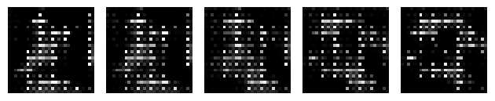

```
Continuous Latent Code 2
```

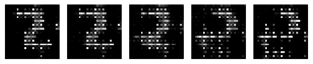

```
Epoch:  1000 | Discriminator Loss: 0.020 | Generator Loss: 4.031 | Q Net Loss: 0.020

Continuous Latent Code 1
```

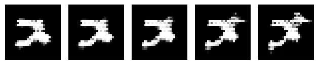

```
Continuous Latent Code 2
```

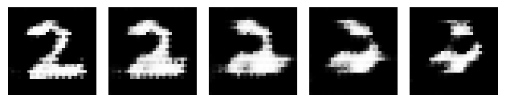

```
Epoch:  1500 | Discriminator Loss: 0.127 | Generator Loss: 2.854 | Q Net Loss: 0.033

Continuous Latent Code 1
```

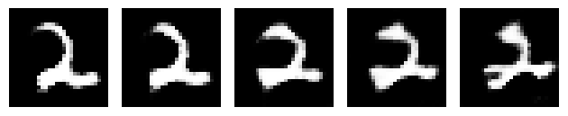

```
Continuous Latent Code 2
```

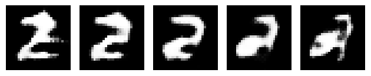

```
Epoch:  2000 | Discriminator Loss: 0.186 | Generator Loss: 7.292 | Q Net Loss: 0.020

Continuous Latent Code 1
```

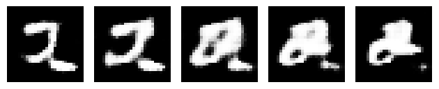

```
Continuous Latent Code 2
```

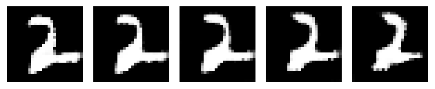

```
Epoch:  2500 | Discriminator Loss: 0.283 | Generator Loss: 5.061 | Q Net Loss: 0.021

Continuous Latent Code 1
```

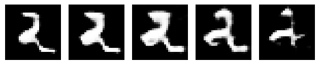

```
Continuous Latent Code 2
```

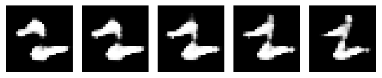

```
Epoch:  3000 | Discriminator Loss: 0.288 | Generator Loss: 5.738 | Q Net Loss: 0.012

Continuous Latent Code 1
```

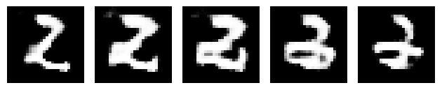

```
Continuous Latent Code 2
```

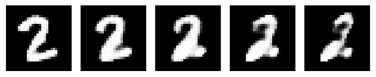

```
Epoch:  3500 | Discriminator Loss: 0.172 | Generator Loss: 5.480 | Q Net Loss: 0.010

Continuous Latent Code 1
```

[8 more figures not shown]

```python
n_iter = 5000
batch_size = 256

real = np.ones((batch_size, 1))
fake = np.zeros((batch_size, 1))

for i in range(n_iter):

    # Train Discriminator
    for _ in range(2):
        z = make_noise(batch_size)
        c = make_code(batch_size)
        noise = np.concatenate([z, c], -1)

        generated_images = generator.predict(noise, verbose = 0)

        idx = np.random.choice(len(train_x), batch_size, replace = False)
        real_images = train_x[idx]

        D_loss_real = discriminator.train_on_batch(real_images, real)
        D_loss_fake = discriminator.train_on_batch(generated_images, fake)
        D_loss = D_loss_real + D_loss_fake

    # Train Generator & Q Net
    for _ in range(1):
        z = make_noise(batch_size)
        c = make_code(batch_size)
        noise = np.concatenate([z, c], -1)

        G_loss = combined_d.train_on_batch(noise, real)
        Q_loss = combined_q.train_on_batch(noise, c)

    # Print Loss
    if (i + 1) % 500 == 0:
        print('Epoch: {:5d} | Discriminator Loss: {:.3f} | Generator Loss: {:.3f} | Q Net Loss: {:.3f}'.format(i + 1, D_loss, G_loss, Q_loss))
        plot_generated_images(generator)
```

```python
images_save_1 = []
images_save_2 = []

for i in range(8):
    z = np.random.randn(1, 62).repeat(8, axis = 0)

    # Continuous Latent Code 1
    c = np.stack([np.linspace(-1, 1, 8), np.zeros(8)]).T
    noise = np.concatenate([z, c], -1)

    generated_images = generator.predict(noise, verbose=0)
    generated_images = generated_images.reshape(8, 28, 28)

    images_save_1.append(generated_images)

    # Continuous Latent Code 2
    c = np.stack([np.zeros(8), np.linspace(-1, 1, 8)]).T
    noise = np.concatenate([z, c], -1)

    generated_images = generator.predict(noise, verbose=0)
    generated_images = generated_images.reshape(8, 28, 28)

    images_save_2.append(generated_images)
```

```
Continuous Latent Code 1
```

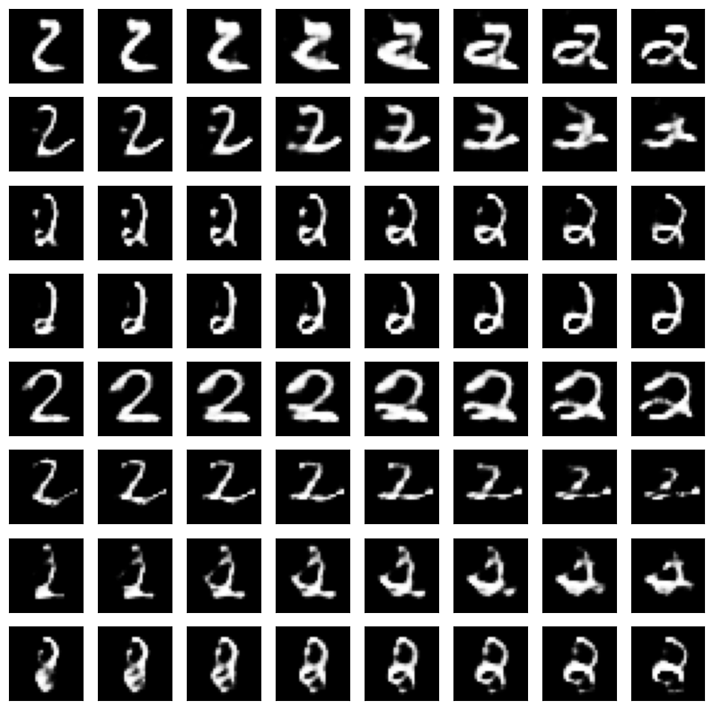

```python
print('Continuous Latent Code 1')
fig, ax = plt.subplots(8, 8, figsize = (10, 10))

for i in range(8):
    for j in range(8):
        ax[i][j].imshow(images_save_1[i][j], 'gray')
        ax[i][j].set_xticks([])
        ax[i][j].set_yticks([])

plt.show()
```

From the results, we can post-hoc interpret what each latent code has learned:

- $c_1$ appears to control the curvature of the tail of the digit 2 — transitioning from a sharply curved, angular tail on the left to a more rounded, looped style on the right

```
Continuous Latent Code 2
```

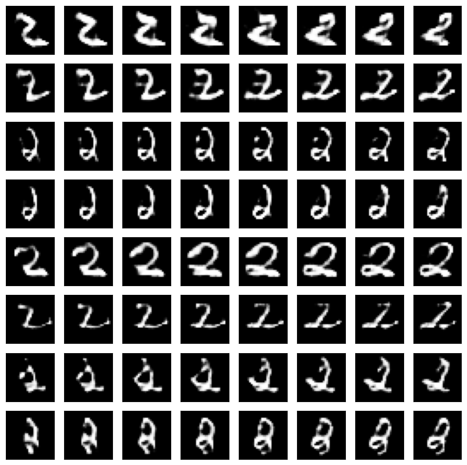

```python
print('Continuous Latent Code 2')
fig, ax = plt.subplots(8, 8, figsize = (10, 10))

for i in range(8):
    for j in range(8):
        ax[i][j].imshow(images_save_2[i][j], 'gray')
        ax[i][j].set_xticks([])
        ax[i][j].set_yticks([])

plt.show()
```

From the results, we can post-hoc interpret what each latent code has learned:

- $c_2$ appears to control the rotation angle — the digit gradually tilts as the code value changes.

These interpretations are post-hoc. The model was never told to learn rotation or curvature — it discovered these attributes entirely on its own, driven only by the mutual information constraint. The smooth, continuous transitions visible across both axes are a characteristic sign of successful disentanglement: each latent code independently controls one interpretable aspect of the output without interfering with the other.

It is also important to note that since these representations are learned from data rather than specified in advance, the specific attributes encoded by each latent code are not guaranteed to be the same across different training runs. A different training run may produce a model where $c_1$ encodes rotation and $c_2$ encodes tail curvature, or where the two codes capture entirely different factors of variation altogether. The mutual information constraint ensures that the latent codes encode something meaningful and disentangled — but it does not determine which specific attributes will be discovered.

# 7. CycleGAN

CycleGAN is an extension of the standard GAN framework designed for image-to-image translation — the task of learning to change the style of an image from one domain to another.

The representative examples are:

- converting Monet paintings to photographs,
- translating zebras to horses, and
- transforming summer landscapes to winter scenes, and vice versa.
- In the bottom row, the same photograph is translated into the styles of four different painters — Monet, Van Gogh, Cezanne, and Ukiyo-e

[figure not shown]

## 7.1. Limitation of Paired Datasets

A natural approach to image-to-image translation would be to train a supervised model on paired examples — an input image and its corresponding target image. As shown in the below figure, paired data provides a clean, direct supervision signal.

However, collecting such paired datasets is impossible in most practical cases. There is no way to obtain a photograph of a horse and its exact zebra equivalent in the same pose, lighting, and background. CycleGAN addresses this by working with **unpaired** data — two independent sets of images from each domain, with no correspondence between them.

As the problem setting becomes more realistic, the assumptions we can make about the data become weaker, and the algorithms must become correspondingly more sophisticated. So far, we have focused on algorithms and network architectures under the assumption that data are well prepared and readily available. However, the cost and time required to prepare training data are far from negligible. Unsupervised learning is generally cheaper than supervised learning, and unpaired data is much easier to obtain than paired data. At the same time, working with less structured data demands more careful and sophisticated algorithm design.

CycleGAN is a good example of this trade-off — it sacrifices the convenience of paired supervision in favor of a more flexible and broadly applicable framework. Let us now see how it overcomes the technical challenges posed by unpaired data.

[figure not shown]

## 7.2. From Naive GAN to CycleGAN

A naive approach would be to train a single generator $G_{XY}$ that takes an image from domain $X$ (horse) and translates it into domain $Y$ (zebra), supervised only by a discriminator in domain $Y$.

In the GAN examples studied so far, the generator takes a noise vector $z$ as input and produces an image. In this case, however, the input is itself an image — the generator must transform one image into another while preserving its content.

This changes the architectural requirements slightly. A simple fully connected or transposed-convolution network is no longer appropriate, because we are not generating an image from a noise — we are transforming an existing one. Instead, CycleGAN uses an autoencoder-style architecture for the generator, as illustrated in the figure.

The generator consists of two parts:

- An encoder that progressively compresses the input image into a compact latent representation, capturing the content of the image in a lower-dimensional space
- A decoder that reconstructs an image from this latent representation, but in the target domain

The latent representation in this autoencoder plays a role analogous to the latent code $z$ in a standard GAN — it is a compressed description of the image content. The key difference is that here the latent space is not explicitly controlled or sampled from a known distribution. It is determined entirely by the encoder's compression of the input image. The decoder then learns to reconstruct from this representation in the style of the target domain, effectively disentangling content from style within the network's internal representation.

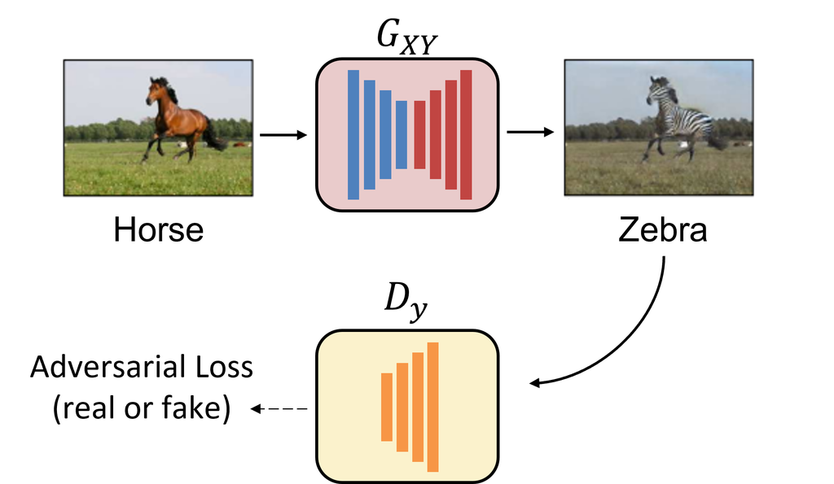

As shown in the figure, this setup has a fundamental problem: the adversarial loss alone does not constrain the generator to preserve the content of the input image. The generator could produce a realistic-looking zebra that has nothing to do with the original horse image — a different pose, different background, or an entirely unrelated scene — and still fool the discriminator.

**Cycle Consistency Loss**

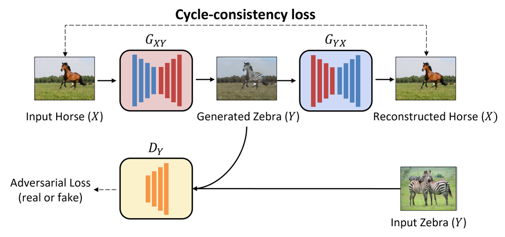

CycleGAN solves this by introducing a second generator $G_{YX}: Y \rightarrow X$ and enforcing a cycle consistency constraint: translating an image from $X$ to $Y$ and then back to $X$ should recover the original image.

$$G_{YX}(G_{XY}(x)) \approx x \qquad G_{XY}(G_{YX}(y)) \approx y$$

As shown in the figure, the horse image is first translated to a zebra by $G_{XY}$, and then translated back to a horse by $G_{YX}$. The cycle consistency loss penalizes any deviation from the original:

$$\mathcal{L}_{\text{cyc}} = \mathbb{E}_{x \sim p_{\text{data}}(x)}\left[\|G_{YX}(G_{XY}(x)) - x\|_1\right] + \mathbb{E}_{y \sim p_{\text{data}}(y)}\left[\|G_{XY}(G_{YX}(y)) - y\|_1\right]$$

This constraint acts as a form of self-supervision that forces the two generators to be consistent with each other and prevents them from making arbitrary mappings.

The full objective combines the adversarial losses for both generators with the cycle consistency loss:

$$\mathcal{L} = \mathcal{L}_{\text{GAN}}(G_{XY}, D_Y) + \mathcal{L}_{\text{GAN}}(G_{YX}, D_X) + \lambda \mathcal{L}_{\text{cyc}}$$

where $\lambda$ controls the relative importance of the cycle consistency loss. The discriminator $D_Y$ judges whether an image belongs to domain $Y$, and $D_X$ judges whether an image belongs to domain $X$. In practice, only one translation direction is often needed — for example, horse to zebra — in which case only $D_Y$ can be used.

# 8. Adversarial Autoencoder (AAE)

In the CycleGAN architecture discussed above, the latent space of the autoencoder-style generator is determined entirely by the encoder's compression of the input — it is not explicitly controlled or constrained to follow any particular distribution. This points to a more fundamental limitation of standard autoencoders.

An autoencoder is a manifold learning model, not a generative model. It learns a compact representation of the training data by mapping inputs to a lower-dimensional latent space and reconstructing them. However, the structure of this latent space is arbitrary — it is shaped differently for each training run, and there is no guarantee that the space is continuous or well-organized. As a result, sampling from the latent space of a standard autoencoder does not reliably produce meaningful or realistic outputs. The autoencoder learns where the training data lives in the latent space, but it does not learn how to fill that space in a way that supports generation.

To use an autoencoder as a generative model, we need to encode data into a controllable latent space — one with a known probability distribution that we can sample from — and then generate new data by decoding samples drawn from that distribution.

This is where the adversarial approach comes in. By introducing a discriminator that encourages the encoder to map data into a latent space that follows a specified prior distribution — such as $\mathcal{N}(0, I)$ — we can impose explicit structure on the latent space. The result is the Adversarial Autoencoder (AAE), which combines the reconstruction objective of an autoencoder with the distributional matching objective of a GAN.

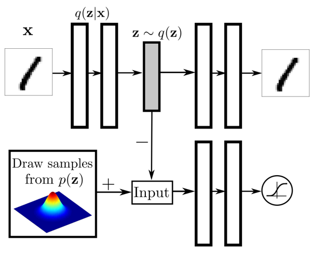

The figure illustrates the AAE architecture. The upper path is a standard autoencoder: the encoder maps an input image $\mathbf{x}$ to a latent representation $\mathbf{z} \sim q(\mathbf{z}|\mathbf{x})$, and the decoder reconstructs the image from $\mathbf{z}$. This path is trained with a standard reconstruction loss.

The lower path introduces the adversarial component. A prior distribution $p(\mathbf{z})$ — such as a standard Gaussian — is specified in advance, and samples are drawn from it. A discriminator is then placed at the latent space to distinguish between two types of inputs:

- $\mathbf{z} \sim q(\mathbf{z})$: latent codes produced by the encoder from real data
- $\mathbf{z} \sim p(\mathbf{z})$: samples drawn from the specified prior distribution

The discriminator is trained to tell these two sources apart, while the encoder is trained to fool the discriminator — producing latent codes that are indistinguishable from samples drawn from $p(\mathbf{z})$. This adversarial objective forces the aggregate posterior $q(\mathbf{z})$ to match the prior $p(\mathbf{z})$, imposing explicit distributional structure on the latent space.

The two objectives are trained jointly:

- The reconstruction loss ensures that the autoencoder faithfully encodes and decodes the input data
- The adversarial loss ensures that the latent space follows the specified prior distribution

Once trained, new data can be generated simply by sampling $\mathbf{z} \sim p(\mathbf{z})$ and passing it through the decoder — something that is not possible with a standard autoencoder, where the structure of the latent space is uncontrolled.

The adversarial idea introduced by GAN — placing a discriminator to provide a learned, adaptive signal — turns out to be a broadly useful principle that extends well beyond image generation. In the AAE, the discriminator is not used to distinguish real images from fake ones, but to match two distributions in the latent space.

## 8.1. Incorporating Label Information

Just as cGAN extends the standard GAN by conditioning on label information, AAE can also incorporate class labels into the adversarial training process.

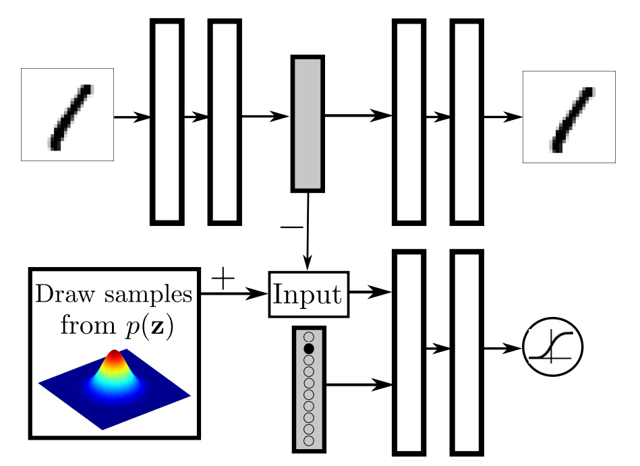

The upper path remains unchanged — the encoder maps the input image to a latent code, and the decoder reconstructs the image from it. The key difference appears in the lower path: when samples are drawn from the prior $p(\mathbf{z})$, the class label (shown as a one-hot encoded vector) is concatenated with the latent code before being passed into the discriminator.

By conditioning the discriminator on the label, the adversarial objective now encourages the encoder to produce latent codes that match the prior distribution for each class independently. The result is a structured latent space in which different regions correspond to different class labels — making the latent space not only continuous and well-organized, but also semantically meaningful.

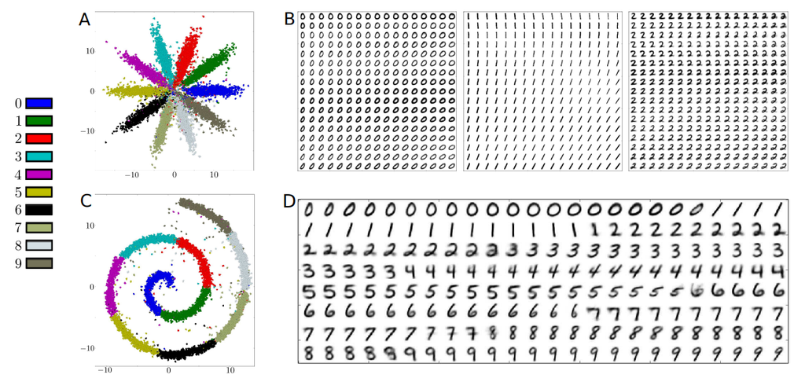

## 8.2. Implementation of AAE

Again, the MNIST dataset will be used to demonstrate how AAE can be implemented.

- To keep the latent space visualization interpretable, only digits 0 through 5 are used, and the latent space is kept two-dimensional so that the distribution of encoded samples can be plotted directly.
- The prior distribution $p(\mathbf{z})$ used here is a Gaussian mixture with six Gaussian clusters arranged in a circle, one for each digit class. Rather than matching a single Gaussian as in a standard AAE, the encoder is encouraged to map each digit class into a separate cluster, producing a structured and interpretable latent space.

```python
import tensorflow as tf
import numpy as np
import matplotlib.pyplot as plt
import random
```

```python
mnist = tf.keras.datasets.mnist

(train_x, train_y), (test_x, test_y) = mnist.load_data()

(train_x, train_y), (test_x, test_y) = mnist.load_data()
train_x, test_x = train_x.reshape(-1, 784)/255.0, test_x.reshape(-1, 784)/255.0
```

```python
# Use only 0,1,2,3,4,5 digits to visualize latent sapce

train_idx0 = np.array(np.where(train_y == 0))
train_idx1 = np.array(np.where(train_y == 1))
train_idx2 = np.array(np.where(train_y == 2))
train_idx3 = np.array(np.where(train_y == 3))
train_idx4 = np.array(np.where(train_y == 4))
train_idx5 = np.array(np.where(train_y == 5))
train_idx = np.sort(np.concatenate((train_idx0, train_idx1, train_idx2, train_idx3, train_idx4, train_idx5), axis = None))

test_idx0 = np.array(np.where(test_y == 0))
test_idx1 = np.array(np.where(test_y == 1))
test_idx2 = np.array(np.where(test_y == 2))
test_idx3 = np.array(np.where(test_y == 3))
test_idx4 = np.array(np.where(test_y == 4))
test_idx5 = np.array(np.where(test_y == 5))
test_idx = np.sort(np.concatenate((test_idx0, test_idx1, test_idx2, test_idx3, test_idx4, test_idx5), axis = None))

train_imgs = train_x[train_idx]
train_labels = train_y[train_idx]
test_imgs = test_x[test_idx]
test_labels = test_y[test_idx]

n_train = train_imgs.shape[0]
n_test = test_imgs.shape[0]

print ("The number of training images : {}, shape : {}".format(n_train, train_imgs.shape))
print ("The number of testing images : {}, shape : {}".format(n_test, test_imgs.shape))
```

```
The number of training images : 36017, shape : (36017, 784)
The number of testing images : 6031, shape : (6031, 784)
```

```python
# Define Structure

# Encoder
encoder = tf.keras.models.Sequential([
    tf.keras.layers.Dense(units = 500, activation = 'relu', input_shape = (784,)),
    tf.keras.layers.Dense(units = 300, activation = 'relu'),
    tf.keras.layers.Dense(units = 2, activation = None)
    ])

# Decoder
decoder = tf.keras.models.Sequential([
    tf.keras.layers.Dense(units = 300, activation = 'relu', input_shape = (2,)),
    tf.keras.layers.Dense(units = 500, activation = 'relu'),
    tf.keras.layers.Dense(units = 784, activation = None)
    ])

# Discriminator
discriminator = tf.keras.models.Sequential([
    tf.keras.layers.Dense(units = 100, activation = 'relu', input_shape = (2,)),
    tf.keras.layers.Dense(units = 100, activation = 'relu'),
    tf.keras.layers.Dense(units = 1, activation =  'sigmoid')
    ])
```

Here, the three models are defined and compiled. Pay attention to which parameters are set to be trainable or untrainable at each point — this may seem unclear at this stage, but will become apparent when the training loop is examined in the next cell.

The `autoencoder` chains the encoder and decoder together and is compiled with a mean squared error reconstruction loss. Both the encoder and decoder parameters are trainable here.

Before compiling the `discriminator`, `encoder.trainable = False` is set. This means that when the discriminator is trained, the encoder parameters will not be updated — only the discriminator parameters will change.

Before building the `combined` model, `discriminator.trainable = False` and `encoder.trainable = True` are set. The `combined` model chains the encoder and the frozen discriminator together. When this model is trained, the gradient flows through the discriminator and into the encoder — but only the encoder parameters are updated. This is the adversarial update step for the encoder.

```python
autoencoder = tf.keras.models.Sequential([encoder, decoder])
autoencoder.compile(optimizer = tf.keras.optimizers.Adam(0.0005),
                    loss = 'mean_squared_error')

encoder.trainable = False
discriminator.compile(optimizer = tf.keras.optimizers.Adam(learning_rate = 0.0005),
                      loss = 'binary_crossentropy')

discriminator.trainable = False
encoder.trainable = True

combined_input = tf.keras.layers.Input(shape = (28*28,))
latent_variable = encoder(combined_input)
combined_output = discriminator(latent_variable )
combined = tf.keras.models.Model(inputs = combined_input, outputs = combined_output)

combined.compile(optimizer = tf.keras.optimizers.Adam(learning_rate = 0.0005),
                 loss = 'binary_crossentropy')
```

```python
def gaussian_mixture_sampler(batchsize, ndim, num_labels):
    if ndim % 2 != 0:
        raise Exception("ndim must be a multiple of 2.")

    def sample(x, y, label, num_labels):
        shift = 1.4
        r = 2 * np.pi / float(num_labels) * float(label)
        new_x = x * np.cos(r) - y * np.sin(r)
        new_y = x * np.sin(r) + y * np.cos(r)
        new_x += shift * np.cos(r)
        new_y += shift * np.sin(r)
        return np.array([new_x, new_y]).reshape((2,)), tf.one_hot(label, num_labels + 1)

    x_var = 0.3
    y_var = 0.05
    x = np.random.normal(0, x_var, (batchsize, ndim // 2))
    y = np.random.normal(0, y_var, (batchsize, ndim // 2))
    z = np.empty((batchsize, ndim), dtype = np.float32)
    z_label = np.empty((batchsize, num_labels + 1), dtype = np.float32)

    for batch in range(batchsize):
        for zi in range(ndim // 2):
            z[batch, zi*2:zi*2+2], z_label[batch] = sample(x[batch, zi], y[batch, zi], random.randint(0, num_labels - 1), num_labels)
    return z, z_label
```

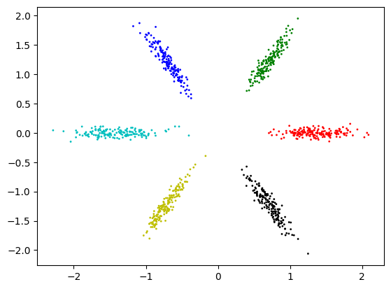

```python
prior, one_hot_label = gaussian_mixture_sampler(1000, 2, 6)

c = np.array(['r', 'g', 'b', 'c', 'y', 'k'])
plt.scatter(prior[:, 0], prior[:, 1], s = 1, c = c[list(np.argmax(one_hot_label, 1))])
plt.show()
```

```python
def plot_latent_space(encoder, samples = 1000):
    idx = np.random.randint(0, train_imgs.shape[0], samples)
    latent_fake = encoder.predict(train_imgs[idx], verbose = 0)

    c = np.array(['r', 'g', 'b', 'c', 'y', 'k'])

    for i, el in enumerate([0, 1, 2, 3, 4, 5]):
        label_idx = np.where(train_labels[idx] == el)[0]
        plt.scatter(latent_fake[label_idx, 0], latent_fake[label_idx, 1], s = 1, label = el, c = c[i])

    plt.legend()
    plt.xticks([])
    plt.yticks([])
    plt.show()
```

Training alternates between three steps in each iteration:

- The autoencoder is updated to minimize reconstruction loss — ensuring the encoder and decoder faithfully represent the input data. At this step, both the encoder and decoder parameters are trainable.
- The discriminator is updated to distinguish between latent codes produced by the encoder and samples drawn from the Gaussian mixture prior. At this step, `encoder.trainable = False` ensures that the encoder parameters are not affected, and only the discriminator is updated.
- The encoder is updated adversarially via the `combined` model to fool the discriminator — pushing the latent codes toward the prior distribution. At this step, `discriminator.trainable = False` freezes the discriminator, and only the encoder parameters are updated through the adversarial gradient.

The careful management of which parameters are trainable at each step is essential for correct adversarial training. The same principle applies here as in the GAN training loop: when updating one network, the other must be held fixed to ensure that the gradient flows in the intended direction.

```
Autoencoder Loss:  0.11396405845880508
Discriminator Loss:  1.3464518785476685
Adversarial Loss:  0.6401848793029785
```

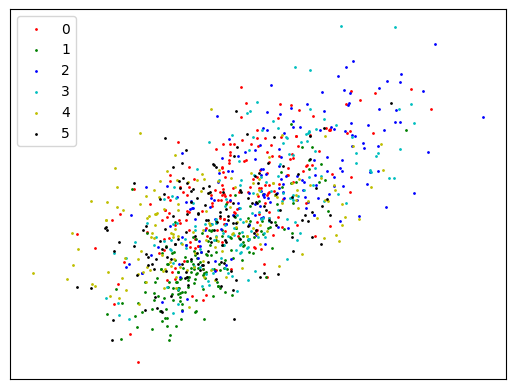

```
Autoencoder Loss:  0.0478895865380764
Discriminator Loss:  1.2937771677970886
Adversarial Loss:  0.7229815125465393
```

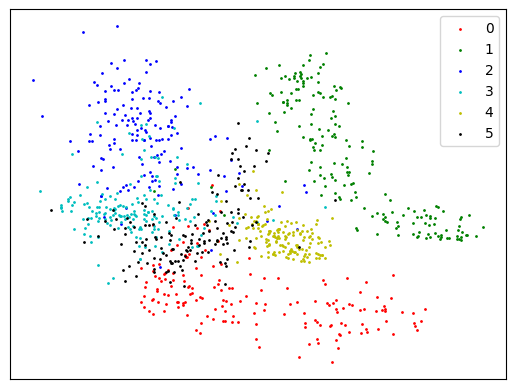

```
Autoencoder Loss:  0.04791981354355812
Discriminator Loss:  1.22506183385849
Adversarial Loss:  0.8402771949768066
```

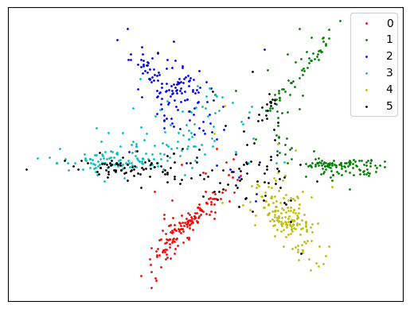

```
Autoencoder Loss:  0.046723414212465286
Discriminator Loss:  1.2455075979232788
Adversarial Loss:  0.8508409261703491
```

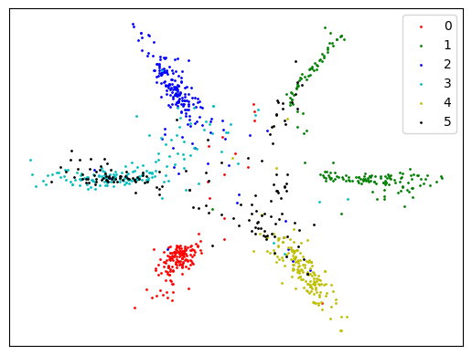

```
Autoencoder Loss:  0.04987465962767601
Discriminator Loss:  1.27111154794693
Adversarial Loss:  0.8673261404037476
```

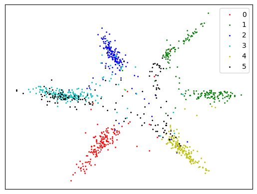

```
Autoencoder Loss:  0.03924637660384178
Discriminator Loss:  1.2927919626235962
Adversarial Loss:  0.9007968306541443
```

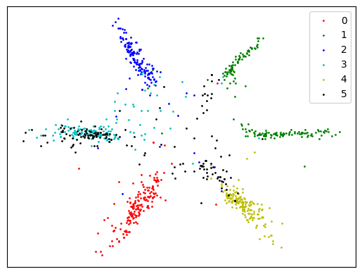

```
Autoencoder Loss:  0.04301917925477028
Discriminator Loss:  1.289901316165924
Adversarial Loss:  0.8124166131019592
```

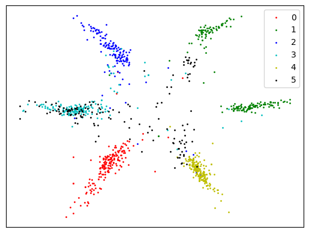

```
Autoencoder Loss:  0.04106577858328819
Discriminator Loss:  1.2537448406219482
Adversarial Loss:  0.8318484425544739
```

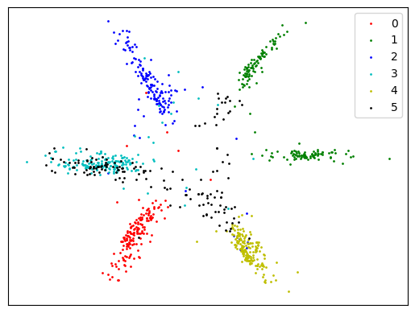

```
Autoencoder Loss:  0.04374618083238602
Discriminator Loss:  1.2305973768234253
Adversarial Loss:  0.9041962623596191
```

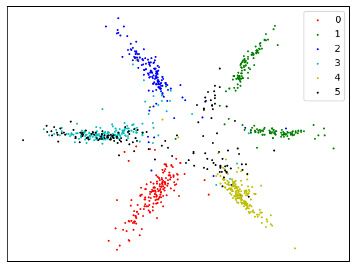

```
Autoencoder Loss:  0.042891405522823334
Discriminator Loss:  1.286674976348877
Adversarial Loss:  0.9378982782363892
```

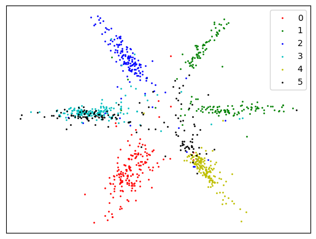

```python
n_iter = 10000
batch_size = 100

fake = np.zeros(batch_size)
real = np.ones(batch_size)

for i in range(n_iter):
    idx = np.random.randint(0, train_imgs.shape[0], batch_size)

    # Train Autoencoder
    AE_loss = autoencoder.train_on_batch(train_imgs[idx], train_imgs[idx])

    # Train Discriminator
    latent_true, _ = gaussian_mixture_sampler(batch_size, 2, 6)
    latent_fake = encoder.predict(train_imgs[idx], verbose = 0)

    D_loss_real = discriminator.train_on_batch(latent_true, real)
    D_loss_fake = discriminator.train_on_batch(latent_fake, fake)
    D_loss = D_loss_real + D_loss_fake

    # Train Encoder
    idx = np.random.randint(0, train_imgs.shape[0], batch_size)

    Adv_loss = combined.train_on_batch(train_imgs[idx], real)

    if i % 1000 == 0:
        print('Autoencoder Loss: ', AE_loss)
        print('Discriminator Loss: ', D_loss)
        print('Adversarial Loss: ', Adv_loss)

        plot_latent_space(encoder)
```

To achieve a truly controlled and semantically meaningful latent space — where each digit class is consistently mapped to a specific region — we need to incorporate label information directly into the training process. This is the motivation for the conditional AAE presented in the next example.

```python
# Encoder
encoder = tf.keras.models.Sequential([
    tf.keras.layers.Dense(units = 500, activation = 'relu', input_shape = (784,)),
    tf.keras.layers.Dense(units = 300, activation = 'relu'),
    tf.keras.layers.Dense(units = 2, activation = None)
    ])

# Decoder
decoder = tf.keras.models.Sequential([
    tf.keras.layers.Dense(units = 300, activation = 'relu', input_shape = (2,)),
    tf.keras.layers.Dense(units = 500, activation = 'relu'),
    tf.keras.layers.Dense(units = 784, activation = None)
    ])

# discriminator_label
discriminator_label = tf.keras.models.Sequential([
    tf.keras.layers.Dense(units = 100, activation = 'relu', input_shape = (2 + 6 + 1,)),
    tf.keras.layers.Dense(units = 100, activation = 'relu'),
    tf.keras.layers.Dense(units = 1, activation =  'sigmoid')
    ])
```

The encoder and decoder architectures are identical to the previous unconditional AAE — the encoder maps a 784-dimensional input to a 2-dimensional latent code, and the decoder reconstructs the 784-dimensional image from it.

The key difference is in the discriminator. In the previous example, `discriminator` took only the 2-dimensional latent code as input. Here, `discriminator_label` takes a concatenated input of dimension $2 + 6 + 1 = 9$ — the 2-dimensional latent code combined with a 7-dimensional one-hot label vector. The 7 dimensions correspond to 6 digit classes plus one additional index reserved for unlabeled samples.

By conditioning the discriminator on the label, the adversarial training can now explicitly encourage each digit class to occupy a specific and consistent region of the latent space — addressing the limitation of the unconditional AAE discussed above.

```python
autoencoder = tf.keras.models.Sequential([encoder, decoder])
autoencoder.compile(optimizer = tf.keras.optimizers.Adam(0.0005),
                    loss = 'mean_squared_error')

encoder.trainable = False
discriminator_label.compile(optimizer = tf.keras.optimizers.Adam(learning_rate = 0.0005),
                            loss = 'binary_crossentropy')

discriminator_label.trainable = False
encoder.trainable = True

combined_input = tf.keras.layers.Input(shape = (28*28 + 6 + 1,))
latent_variable = encoder(combined_input[:, :28*28])
latent_label = tf.concat([latent_variable, combined_input[:, 28*28:]], 1)
combined_label_output = discriminator_label(latent_label)
combined_label = tf.keras.models.Model(inputs = combined_input, outputs = combined_label_output)

combined_label.compile(optimizer = tf.keras.optimizers.Adam(learning_rate = 0.0005),
                       loss = 'binary_crossentropy')
```

```
Autoencoder Loss:  0.10694870352745056
Discriminator Loss:  2.0750131011009216
Adversarial Loss:  0.6890000700950623
```

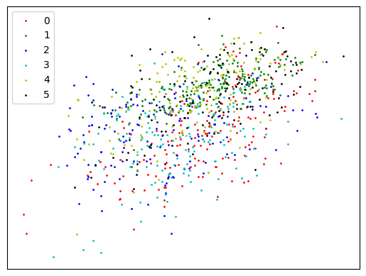

```
Autoencoder Loss:  0.05089759826660156
Discriminator Loss:  1.3033279494848102
Adversarial Loss:  0.7591390013694763
```

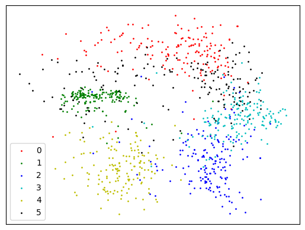

```
Autoencoder Loss:  0.044531725347042084
Discriminator Loss:  1.1924733045825633
Adversarial Loss:  0.9256393313407898
```

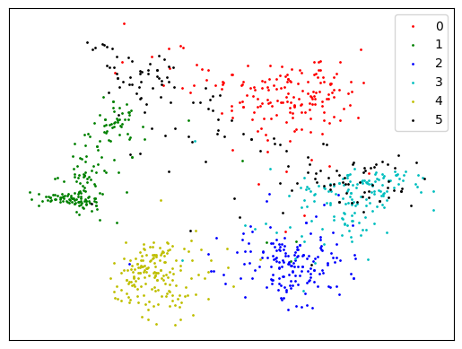

```
Autoencoder Loss:  0.043471693992614746
Discriminator Loss:  1.2489777825121564
Adversarial Loss:  0.8828380703926086
```

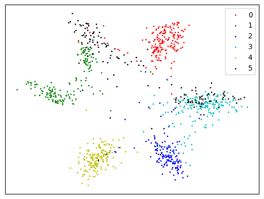

```
Autoencoder Loss:  0.04346089065074921
Discriminator Loss:  1.203024471810295
Adversarial Loss:  0.7591931819915771
```

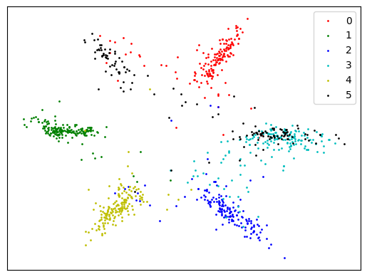

```
Autoencoder Loss:  0.04413749650120735
Discriminator Loss:  1.1958808300436488
Adversarial Loss:  0.8612193465232849
```

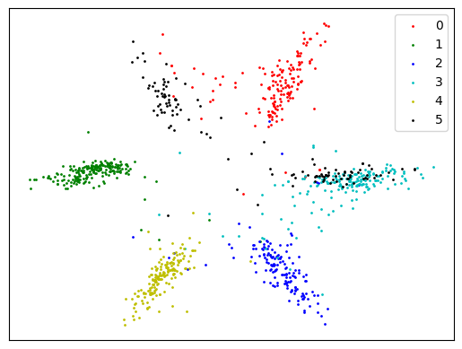

```
Autoencoder Loss:  0.04201776906847954
Discriminator Loss:  1.2356403472762238
Adversarial Loss:  0.8549310564994812
```

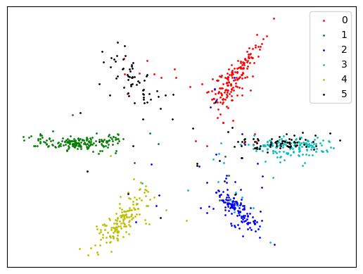

```
Autoencoder Loss:  0.04225203022360802
Discriminator Loss:  1.2348333907218603
Adversarial Loss:  0.9510146975517273
```

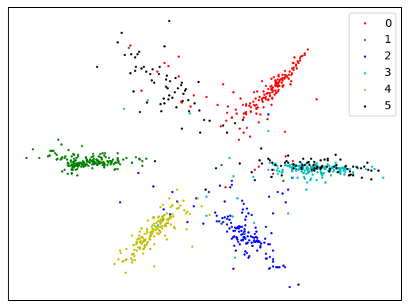

```
Autoencoder Loss:  0.04253502935171127
Discriminator Loss:  1.1383356048092157
Adversarial Loss:  0.9228068590164185
```

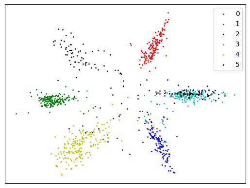

```
Autoencoder Loss:  0.04324803501367569
Discriminator Loss:  1.1546122021292007
Adversarial Loss:  1.0049819946289062
```

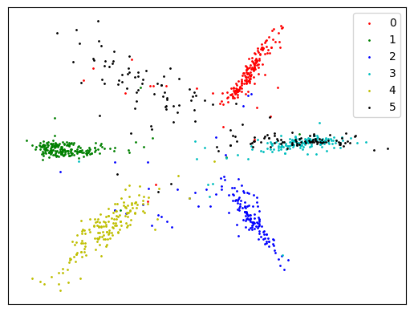

```python
n_iter = 10000
batch_size = 100

fake = np.zeros(batch_size)
real = np.ones(batch_size)

for i in range(n_iter):
    idx = np.random.randint(0, train_imgs.shape[0], batch_size)

    # Train Autoencoder
    AE_loss = autoencoder.train_on_batch(train_imgs[idx], train_imgs[idx])

    # Train Discriminator
    # positive phase
    latent_true, one_hot_true_label = gaussian_mixture_sampler(batch_size, 2, 6)
    latent_true = tf.concat([latent_true, one_hot_true_label], 1)
    D_loss_real = discriminator_label.train_on_batch(latent_true, real)

    latent_true, one_hot_true_label = gaussian_mixture_sampler(batch_size, 2, 6)
    one_hot_fake_label = tf.one_hot([6] * batch_size, 6 + 1)
    latent_true = tf.concat([latent_true, one_hot_fake_label], 1)
    D_loss_real += discriminator_label.train_on_batch(latent_true, real)

    latent_fake = encoder.predict(train_imgs[idx], verbose = 0)
    one_hot_fake_label = tf.one_hot([6] * batch_size, 6 + 1)
    latent_fake = tf.concat([latent_fake, one_hot_fake_label], 1)
    D_loss_fake = discriminator_label.train_on_batch(latent_fake, fake)

    D_loss = D_loss_real + D_loss_fake

    # Train Generator
    idx = np.random.randint(0, train_imgs.shape[0], batch_size)
    one_hot_fake_label = tf.one_hot([6] * batch_size, 6 + 1)

    train_input = tf.concat([train_imgs[idx], one_hot_fake_label], 1)

    Adv_loss = combined_label.train_on_batch(train_input, real)

    if i % 1000 == 0:
        print('Autoencoder Loss: ', AE_loss)
        print('Discriminator Loss: ', D_loss)
        print('Adversarial Loss: ', Adv_loss)

        plot_latent_space(encoder)
```

```python
%%javascript
$.getScript('https://kmahelona.github.io/ipython_notebook_goodies/ipython_notebook_toc.js')
```